# Analiza medijske prisutnosti Hrvatske Narodne Banke u digitalnom medijskom prostoru

22. srpnja 2025.

```r
knitr::opts_chunk$set(echo = FALSE, message = FALSE, warning = FALSE, fig.width = 12, fig.height = 7, dpi = 200)
```

Uvod

Ovaj dokument predstavlja analizu prisutnosti Hrvatske narodne banke (HNB) u digitalnom medijskom prostoru za razdoblje od 1. siječnja 2021. do 31. prosinca 2023. godine. Svrha analize jest pružiti sustavan pregled medijskog ekosustava u kojem se komuniciraju i interpretiraju teme vezane uz rad HNB-a.

Analiza, temeljena na uzorku od preko 19.000 medijskih objava, usmjerena je na tri ključna područja:

-> Identifikacija dominantnih platformi na kojima se odvija diskurs o HNB-u.

-> Identifikacija ključnih medijskih aktera i njihova produktivnost.

-> Analiza dinamike utjecaja kroz metrike dosega i angažmana publike.

Izvješće je strukturirano tako da polazi od makro-pregleda digitalnih platformi, prelazi na mikro-analizu najutjecajnijih medijskih izvora te završava sintezom u obliku “Mape utjecaja”.

# I. Makro-analiza: Distribucija sadržaja i angažmana

Prvi dio analize usmjeren je na kvantificiranje i usporedbu digitalnih platformi prema volumenu objava i ostvarenom angažmanu javnosti.

#### **Dominacija internetskih portala**

Analiza volumena medijskih objava potvrđuje da su internetski portali primarni kanal za distribuciju sadržaja o Hrvatskoj narodnoj banci. Njihova dominacija u produkciji očekivana je s obzirom na ulogu medija u prenošenju službenih priopćenja, odluka i izvješća.

[figure not shown]

#### **Uloga društvenih mreža i video platformi**

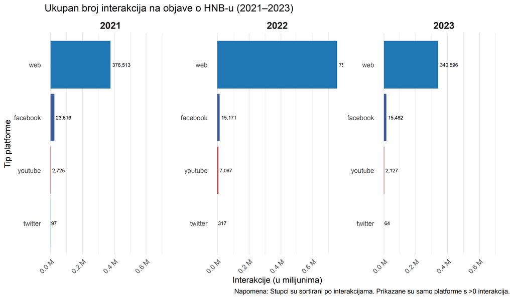

#### **Relativna važnost platformi u medijskom ekosustavu**

[figure not shown]

# 2. Mikro pogled: Najutjecajniji akteri

Drugi dio analize fokusira se na identifikaciju najutjecajnijih pojedinačnih medijskih izvora unutar tri ključne platforme: weba, YouTubea i Facebooka.

#### **Pregled vodećih izvora prema ostvarenim interakcijama**

Rangiranje aktera prema ukupnom broju interakcija ukazuje na specifičnu strukturu za svaku platformu:

-> Web: Dominiraju vodeći nacionalni mediji i specijalizirani poslovni portali.

-> YouTube: Ističu se kanali medijskih kuća, ekonomski podcasti i analitičari.

-> Facebook: Ekosustav je najraznolikiji i uključuje medijske kuće, političke aktere te stranice posvećene ekonomskim temama.

Produktivnost (ukupan broj objava) ukazuje na različite strategije aktera – od onih koji se oslanjaju na visok volumen objava do onih koji ostvaruju utjecaj manjim brojem objava s visokim angažmanom.

[figure not shown]

# III. Sinteza: Mapa utjecaja najvažnijih aktera

Završni dio analize objedinjuje prethodne nalaze u jedinstvenom vizualnom prikazu. “Mapa utjecaja” pozicionira ključne aktere u dvodimenzionalnom prostoru definiranom angažmanom (os X) i dosegom (os Y). Ovaj pristup omogućuje klasifikaciju aktera prema prirodi njihovog utjecaja.

Osi su prikazane na logaritamskoj skali radi bolje preglednosti širokog raspona vrijednosti. Na temelju pozicije, akteri se mogu svrstati u četiri arhetipa:

-> Divovi (gore desno): Akteri s visokim dosegom i visokim angažmanom.

-> Megafoni (gore lijevo): Akteri s visokim dosegom, ali nižim angažmanom.

-> Graditelji zajednica (dolje desno): Akteri s nižim dosegom, ali iznimno visokim angažmanom.

-> Nišni igrači (dolje lijevo): Akteri s umjerenim dosegom i angažmanom.

Osi su na logaritamskoj skali kako bi se bolje prikazao širok raspon vrijednosti.

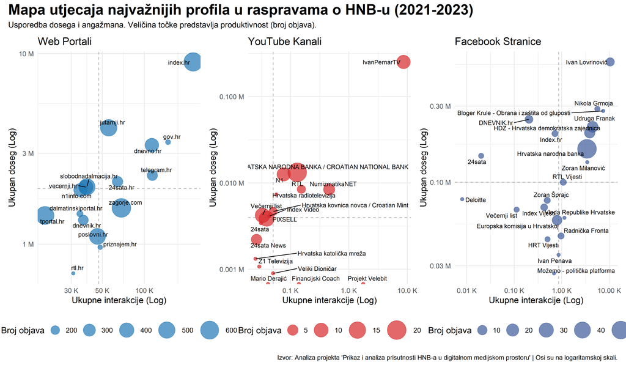

# Zaključak i sljedeći koraci

Provedena analiza pruža kvantitativni temelj za razumijevanje digitalnog medijskog okruženja Hrvatske narodne banke. Glavni nalazi su:

-> Diverzificiranost aktera: Ključni izvori utjecaja razlikuju se od platforme do platforme, što upućuje na segmentiranost publike i komunikacijskih kanala.

-> Višedimenzionalnost utjecaja: Učinkovitost medijskog aktera ovisi o ravnoteži između produktivnosti, dosega i sposobnosti poticanja angažmana.